# Updates to Color Mapping Functions

Mae Hutchison

2026-06-29

# Source code

**mapColorRamp()**

```r
mapColorRamp <- function(shape, column,
                         breaks=8, break.style="quantile",
                         map.title="Sequential Choropleth Map",
                         palette="Oranges",
                         colorblind=FALSE,
                         reverse=FALSE,
                         legend.title=column,
                         legend.digits=3,
                         legend.pos="bottomleft",
                         legend.cex=1,
                         legend.bty='n',
                         legend.col=1,
                         legend.inset=0,
                         add.to.map=FALSE,
                         plot.axes=TRUE,
                         plot.border=grDevices::grey(0.9),
                         na.color=grDevices::grey(0.96),
                         na.label="NA",
                         output.breaks=FALSE){
  stopifnot(
    "shape must be a SpatialPolygonsDataFrame" =
      methods::is(shape, "SpatialPolygonsDataFrame")
    ,"column must be a character string name of column" = methods::is(column, "character")
    ,"column must be in shape spatial data frame" =
      column %in% names(shape))

  ## get data to plot
  data <- shape[[column]]

  if (length(unique(na.omit(data))) < 2) {
    stop("column '", column
         , "' has fewer than 2 unique non-NA values; cannot compute breaks.")
  }

  ## define breaks and color assignment
  class.intervals <-  suppressWarnings( # supress warning for NAs
    classInt::classIntervals(data, n=breaks, style=break.style)
  )
  breaks.vec <- as.numeric(class.intervals$brks)
  pal <- .resolve_palette(palette, breaks, category='seq',
                          reverse=reverse, colorblind=colorblind)
  map.col <- pal[findInterval(data, breaks.vec, rightmost.closed=TRUE)]
  legend.labs <- .legend_labels(round(breaks.vec,digits=legend.digits))

  if (anyNA(data)){
    map.col[is.na(data)] <- na.color       # Set NA's to light grey
    pal <- c(pal[1:breaks], na.color)      # Augment legend color
    legend.labs <- c(legend.labs, na.label)  # Augment legend name
  }

  # -- map panel --
  sp::plot(shape, col=map.col
           , border=plot.border
           , axes=plot.axes,
           add=add.to.map)
  graphics::legend(legend.pos, title=legend.title
                   ,legend=legend.labs
                   , fill=pal
                   , bty=legend.bty
                   , ncol=legend.col
                   , cex=legend.cex
                   , inset = legend.inset)
  graphics::title(map.title)
  graphics::box()

  if(output.breaks){
    output <- list(class.intervals=class.intervals, pal=pal,
                   legend.labs=legend.labs)
    return(output)
  }
}
```

**palette_hist()**

```r
palette_hist <- function(class.intervals, pal = NULL, title = "",
                         equal.width = FALSE, bins = NULL) {

  # Accept either a named list(class.intervals=, pal=) or separate arguments
  if (is.list(class.intervals) &&
      all(c("class.intervals", "pal") %in% names(class.intervals))) {
    pal             <- class.intervals$pal
    class.intervals <- class.intervals$class.intervals
  }
  if (is.null(pal)) stop("pal must be provided either as a separate argument or in the list")

  # Auto-enable equal.width if bins is explicitly supplied
  if (!is.null(bins)) equal.width <- TRUE

  main_title <- if (nchar(title) > 0) title else "Distribution"

  if (!equal.width) {
    graphics::hist(class.intervals$var,
                   breaks = class.intervals$brks,
                   freq   = FALSE,
                   col    = pal,
                   border = grDevices::grey(0.85),
                   main   = main_title,
                   xlab   = "Value",
                   ylab   = "Density",
                   las    = 1)

  } else {
    n_classes <- length(pal)

    # Default: 5 equal-width bins per class interval
    # Override with bins= but warn if not a clean multiple
    if (is.null(bins)) {
      bins <- n_classes * 5L
    } else {
      if (bins %% n_classes != 0L) {
        warning(sprintf(
          "bins (%d) is not a multiple of the number of class intervals (%d). Bar colors may not align cleanly with breaks.",
          bins, n_classes
        ))
      }
    }

    # Force exact breakpoints so bins align with class-interval boundaries
    data_range  <- range(class.intervals$var, na.rm = TRUE)
    bin_breaks  <- seq(data_range[1], data_range[2], length.out = bins + 1)

    h <- graphics::hist(class.intervals$var, breaks = bin_breaks, plot = FALSE)

    bar_colors <- pal[
      findInterval(h$mids, class.intervals$brks, rightmost.closed = TRUE)
    ]

    graphics::plot(h,
                   col    = bar_colors,
                   border = grDevices::grey(0.85),
                   main   = main_title,
                   freq   = FALSE,
                   xlab   = "Value",
                   ylab   = "Density",
                   las    = 1)
  }

  graphics::abline(v   = class.intervals$brks,
                   col = grDevices::grey(0.4),
                   lty = 2,
                   lwd = 0.8)
}
```

**Utility Functions**

```r
#' @noRd
.legend_labels <- function(vec, under = "under", over = "over",
                     between = "-", reverse = FALSE) {

  if (length(vec) < 3)
    stop("vec must have at least 3 elements")

  if (reverse) {
    vec   <- rev(vec)
    under <- "over"
    over  <- "under"
  }

  lx  <- length(vec)
  res <- character(lx - 1)

  res[1]      <- paste(under, vec[2])
  res[lx - 1] <- paste(over,  vec[lx - 1])

  if (lx > 3)
    res[2:(lx - 2)] <- paste(vec[2:(lx - 2)], between, vec[3:(lx - 1)])

  res
}

#' @noRd
.resolve_palette <- function(palette, n, reverse = FALSE, category='any',
                             colorblind=FALSE) {
  options<-if(category %in% c('seq', 'div', 'qual')){
    RColorBrewer::brewer.pal.info[RColorBrewer::brewer.pal.info$category == category, ]
  }else{
    RColorBrewer::brewer.pal.info
  }

  if (colorblind){
    options <- options[options$colorblind==TRUE,]
  }

  if (palette %in% rownames(options)){
    cols <- RColorBrewer::brewer.pal(n, palette)
  } else {
    # Fall back to RColorBrewer Orange
    cols <- RColorBrewer::brewer.pal(n, "Oranges")
    warning("Could not resolve palette, defaulting to RColorBrewer Orange")
  }

  if (reverse) cols <- rev(cols)
  cols
}
```

# MapColorRamp

Major changes:

- input is now in the form `mapColorRamp(shape, column)`, requiring the `column` to be a character string name of a column in the data frame associated with the `SpatialPolygonsDataFrame`, `shape`
- added `palette` option where user can pass the name of any `RColorBrewer` sequential palette. Invalid options default back to `"Oranges"`
- added `output.breaks` option that returns a named list of the `ClasssIntervals` object, resolved color palette, and legend labels # added `break.style` option to pass to `ClassIntervals`

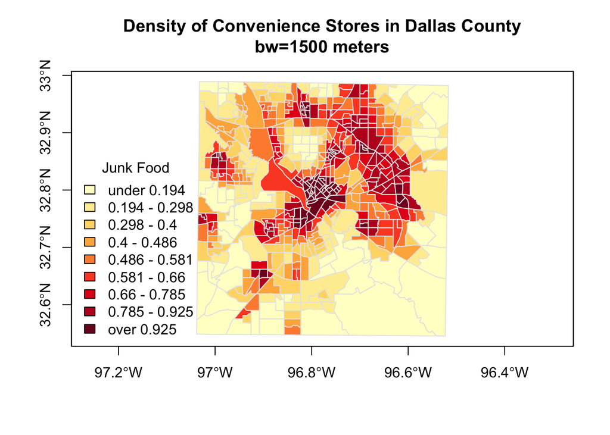

```r
data("tractShp", package="TexMix")

ramp <- mapColorRamp(tractShp, 'bad1500D', palette='YlOrRd', breaks=9,
     map.title="Density of Convenience Stores in Dallas County\nbw=1500 meters",
     legend.title="Junk Food", output.breaks=TRUE)
```

```r
(ramp)
```

```
## $class.intervals
## style: quantile
## [0.01326947,0.1936428)  [0.1936428,0.2979504)  [0.2979504,0.3998867)
##                     59                     59                     58
##  [0.3998867,0.4862996)  [0.4862996,0.5813205)  [0.5813205,0.6602785)
##                     59                     59                     58
##  [0.6602785,0.7852318)  [0.7852318,0.9245865)    [0.9245865,1.75494]
##                     59                     59                     59
##
## $pal
## [1] "#FFFFCC" "#FFEDA0" "#FED976" "#FEB24C" "#FD8D3C" "#FC4E2A" "#E31A1C"
## [8] "#BD0026" "#800026"
##
## $legend.labs
## [1] "under 0.194"   "0.194 - 0.298" "0.298 - 0.4"   "0.4 - 0.486"
## [5] "0.486 - 0.581" "0.581 - 0.66"  "0.66 - 0.785"  "0.785 - 0.925"
## [9] "over 0.925"
```

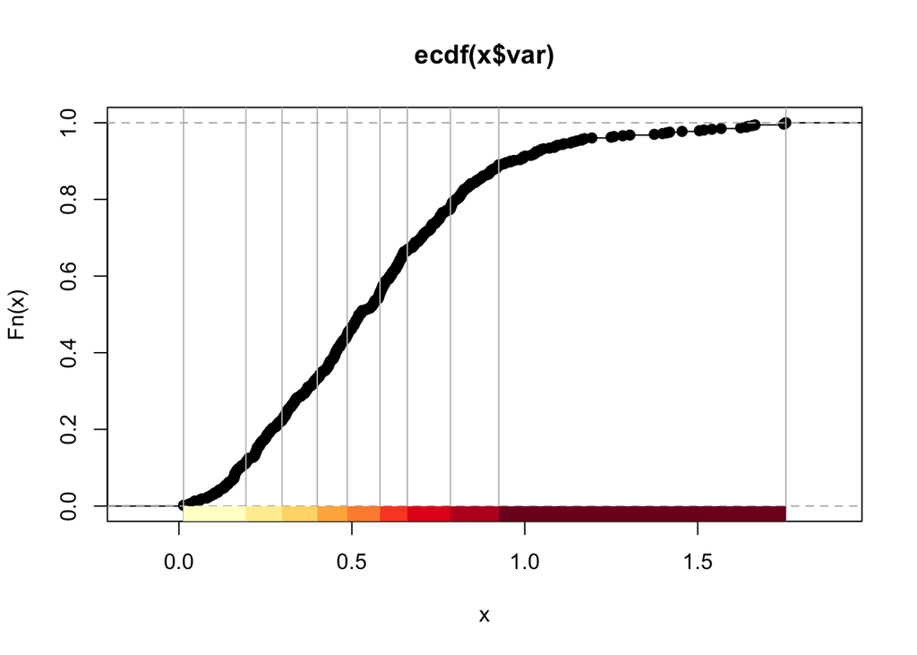

```r
# plot.classIntervals
plot(ramp$class.intervals, pal=ramp$pal)
```

Passing a non-valid or non-sequential `RColorBrewer` palette throws a warning and reverts back to the default:

```
## Warning in .resolve_palette(palette, breaks, category = "seq", reverse =
## reverse, : Could not resolve palette, defaulting to RColorBrewer Orange
```

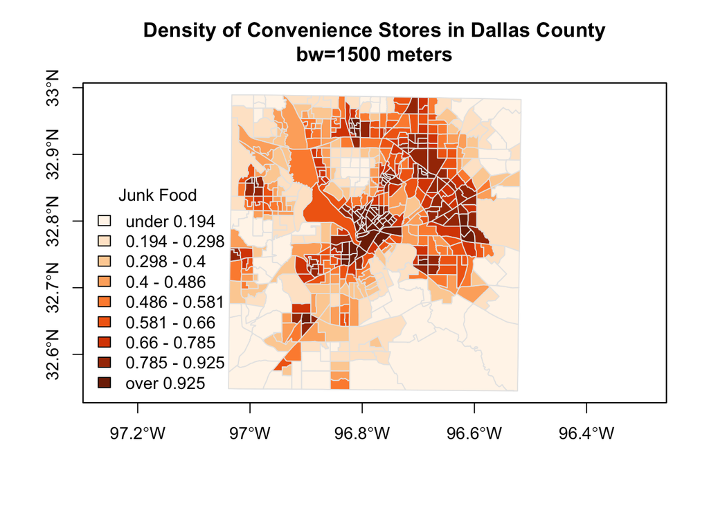

```r
mapColorRamp(tractShp, 'bad1500D', palette='Set1', breaks=9,
     map.title="Density of Convenience Stores in Dallas County\nbw=1500 meters",
     legend.title="Junk Food")
```

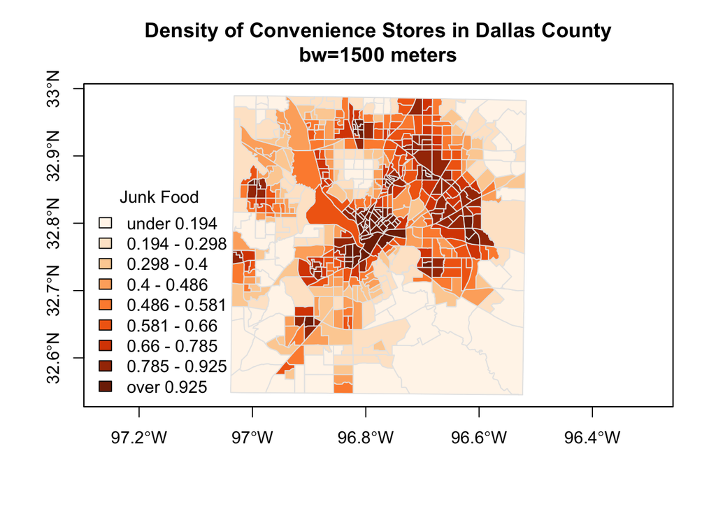

```r
mapColorRamp(tractShp, 'bad1500D', palette='fakePalette', breaks=9,
     map.title="Density of Convenience Stores in Dallas County\nbw=1500 meters",
     legend.title="Junk Food")
```

`break.style` allows for different break calculation strategies

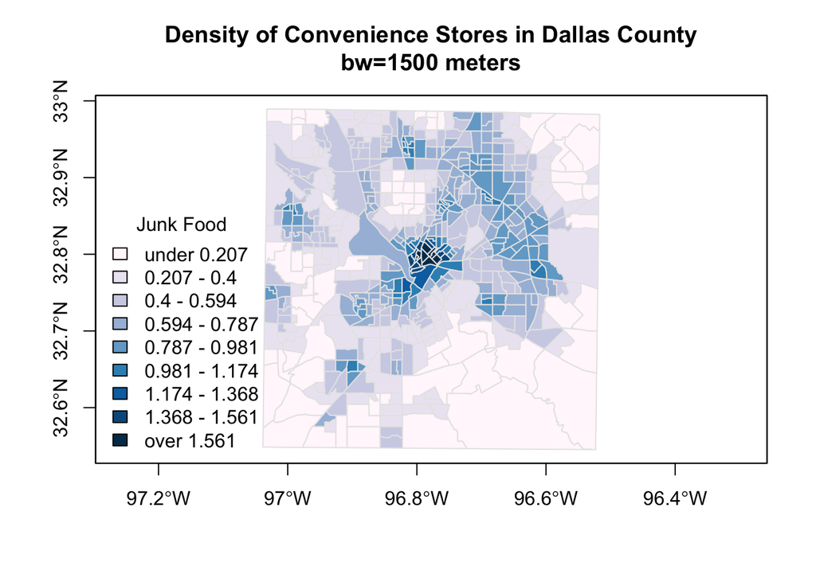

```r
equal <- mapColorRamp(tractShp, 'bad1500D', palette='PuBu'
             , breaks=9, break.style = 'equal',
     map.title="Density of Convenience Stores in Dallas County\nbw=1500 meters",
     legend.title="Junk Food", output.breaks = T)
```

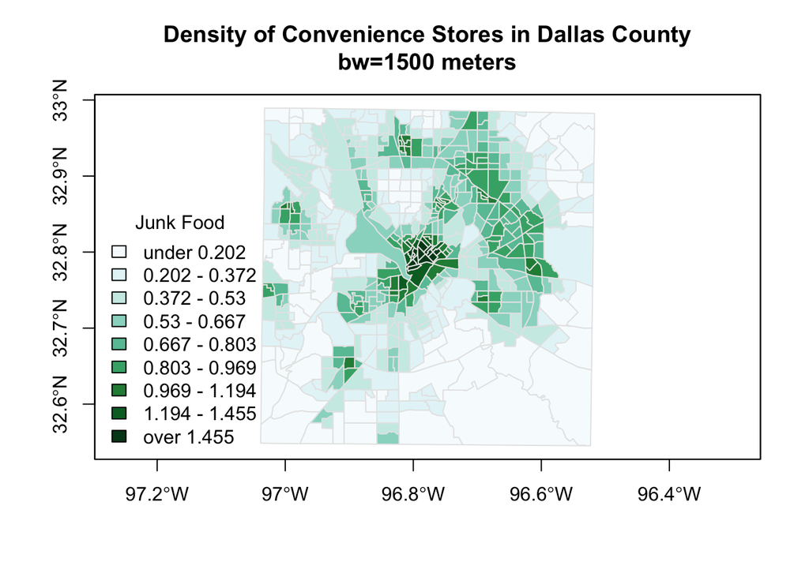

```r
jenks <- mapColorRamp(tractShp, 'bad1500D', palette='BuGn'
             , breaks=9, break.style = 'jenks',
     map.title="Density of Convenience Stores in Dallas County\nbw=1500 meters",
     legend.title="Junk Food", output.breaks = T)
```

Other optional arguments exposed:

```r
 colorblind=FALSE,
 reverse=FALSE,
 legend.title=column,
 legend.digits=3,
 legend.pos="bottomleft",
 legend.cex=1,
 legend.bty='n',
 legend.col=1,
 legend.inset=0,
 add.to.map=FALSE,
 plot.axes=TRUE,
 plot.border=grDevices::grey(0.9),
 na.color=grDevices::grey(0.96),
 na.label="NA"
```

Note that `colorblind` argument is redundant at time of writing due to all sequential `RColorBrewer` palettes being colorblind safe; it is included for consistency with future implementations of `mapColorQual()` and `mapBiPolar()`.

# palette_hist()

`palette_hist()` can directly plot a colored histogram from the output of `mapColorRamp(output.breaks=TRUE)`

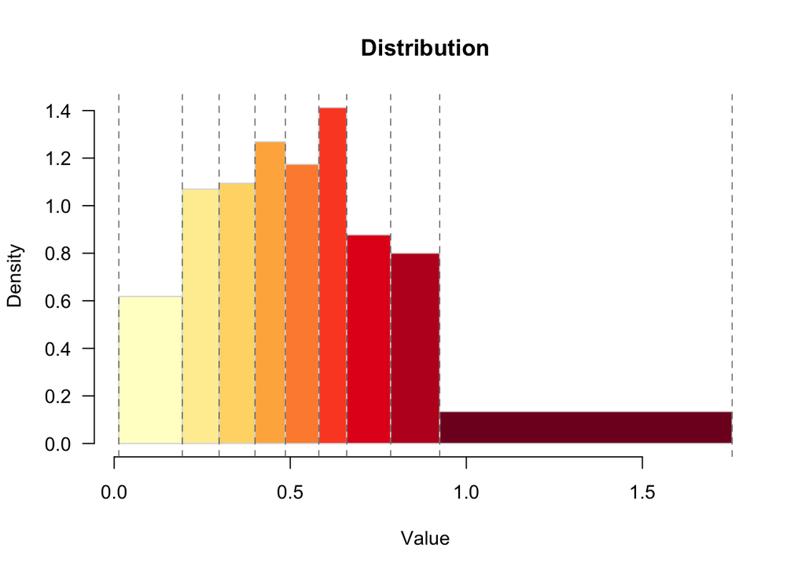

```r
palette_hist(ramp)
```

It can also accept a `classIntervals` and `pal` object separately

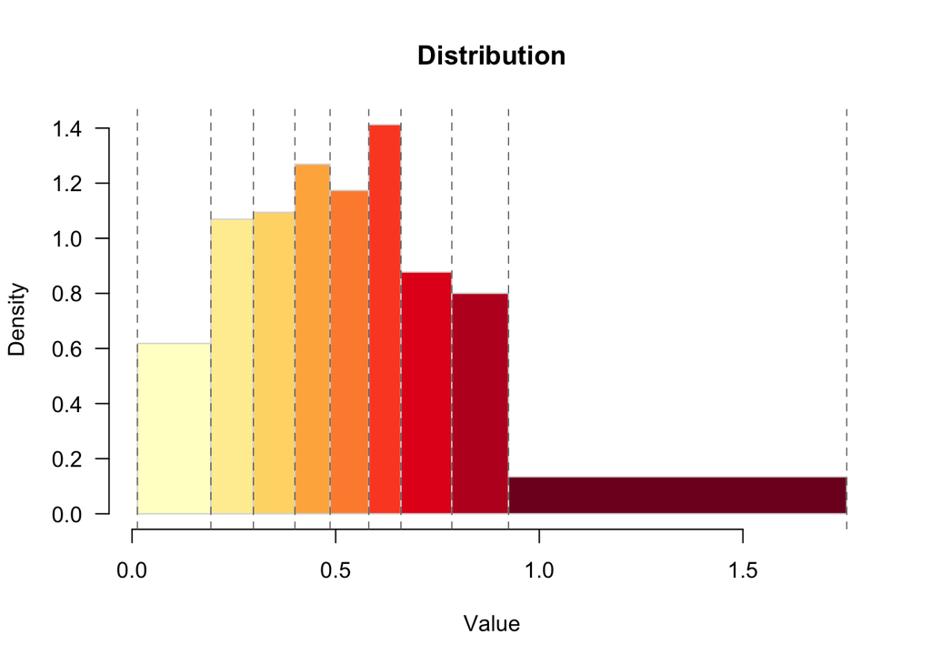

```r
palette_hist(ramp$class.intervals, ramp$pal)
```

Force a standard histogram with equal-width bins:

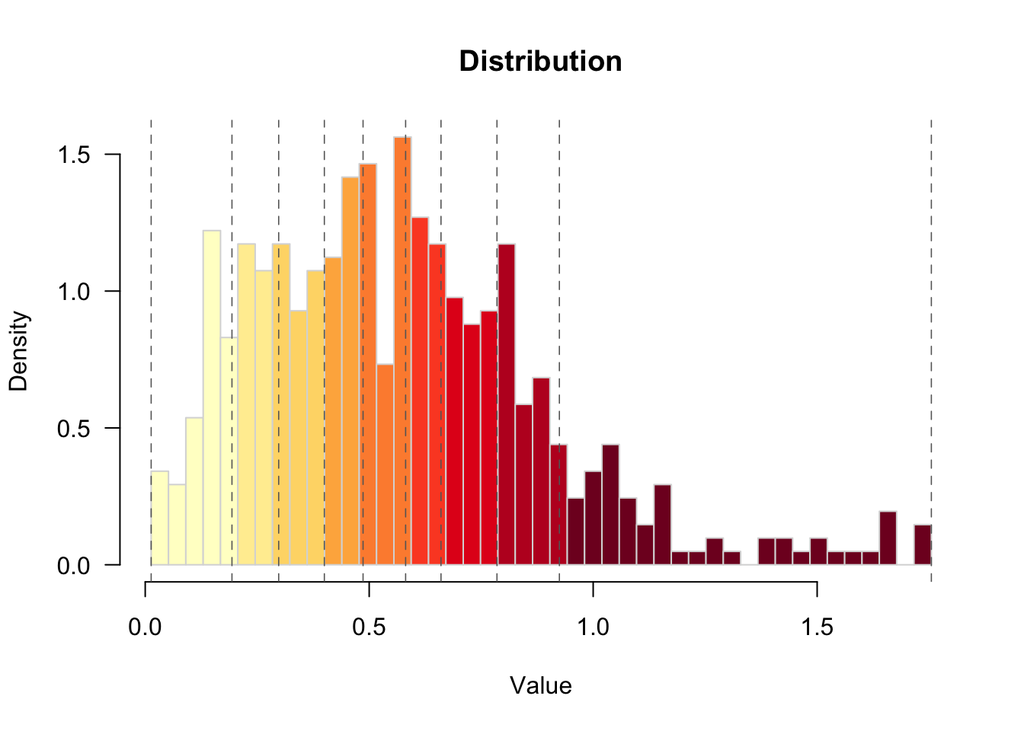

```r
palette_hist(ramp, equal.width = T)
```

Manually set number of bins (forces equal-width bins):

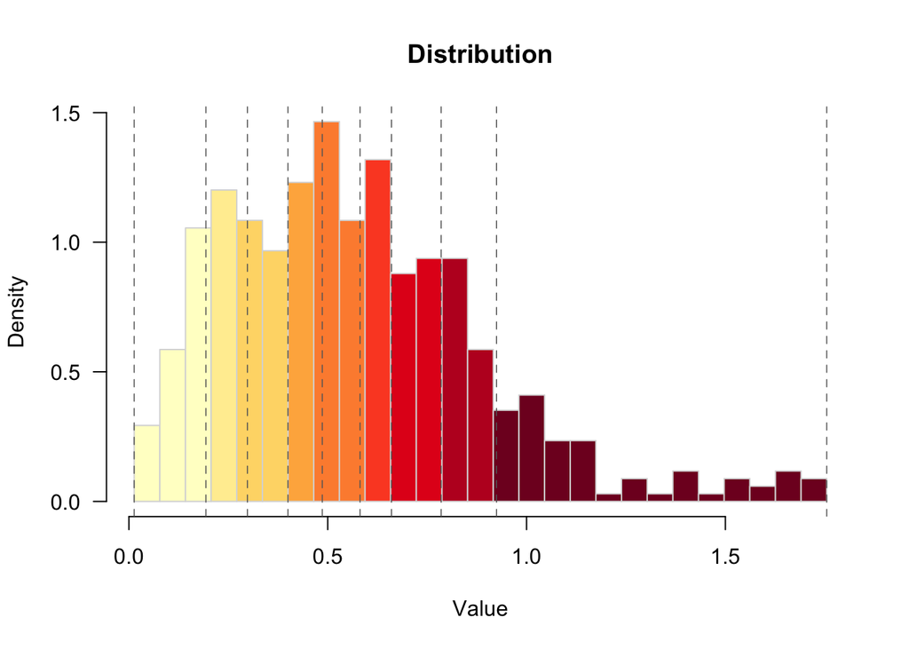

```r
palette_hist(ramp, bins = 27)
```

Warning for bin-color misalignment:

```
## Warning in palette_hist(equal, bins = 6): bins (6) is not a multiple of the
## number of class intervals (9). Bar colors may not align cleanly with breaks.
```

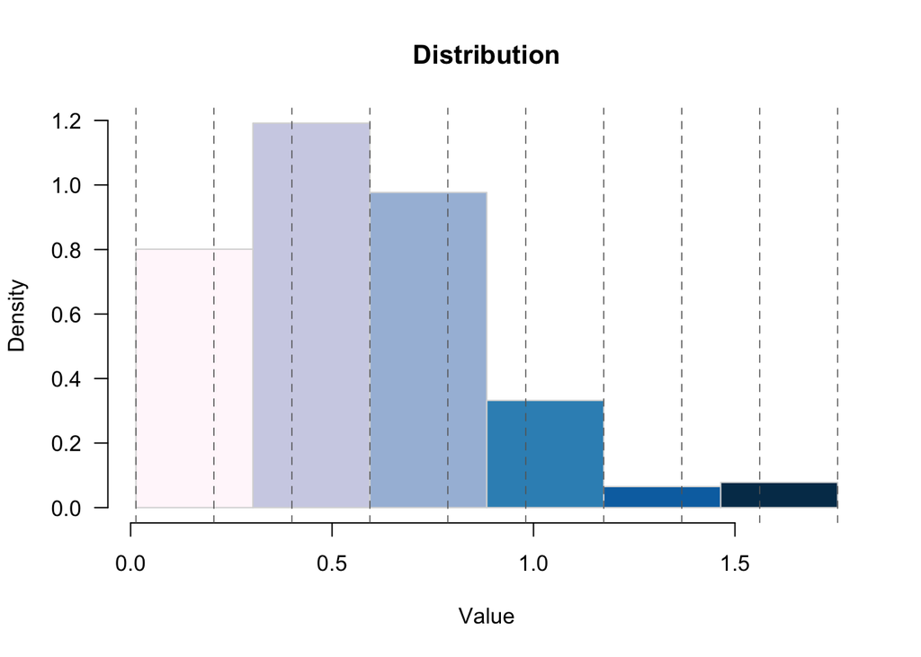

```r
palette_hist(equal, bins = 6)
```